# Inteligência Artificial como Instrumento de Medição

Validação Estatística e Reprodutibilidade

Prof. Dr. Jodavid Ferreira · Departamento de Estatística · UFPE

II DataPOL · 24 a 26 de novembro de 2026 · CCEN/UFPE

“O futuro traz novas perguntas.  
Os dados ampliam nossas formas de responder.”

…mas **quem mede a régua?**

## Duas perguntas para hoje

### Substantiva

Quando o Congresso legisla sobre **IA**, ele quer **punir**, **regular** ou **promover**?

E isso varia entre campos políticos?

### Metodológica

Se usarmos um **LLM** para responder, **como sabemos se a resposta está certa**?

E como **reproduzir** a resposta daqui a dois anos?

> Na I edição do DataPOL vocês viram como **usar** IA para analisar textos. Hoje vamos **medir** com ela e medir o erro dela.

## Por que agora?

- **Eleições de 2026**: primeiras eleições gerais sob a Res. TSE nº 23.755/2026 (rotulagem obrigatória, deepfakes proibidos, IA não pode recomendar voto)
- **Marco Legal da IA (PL 2338/2023)**: aprovado no Senado em dez/2024, **aguardando parecer** na Câmara (votação adiada para depois das eleições)
- **304 projetos de lei** sobre IA no Congresso, 120 só em 2026
- LLMs viraram infraestrutura de pesquisa, mas **instáveis, sensíveis ao prompt e enviesados**

## A explosão legislativa

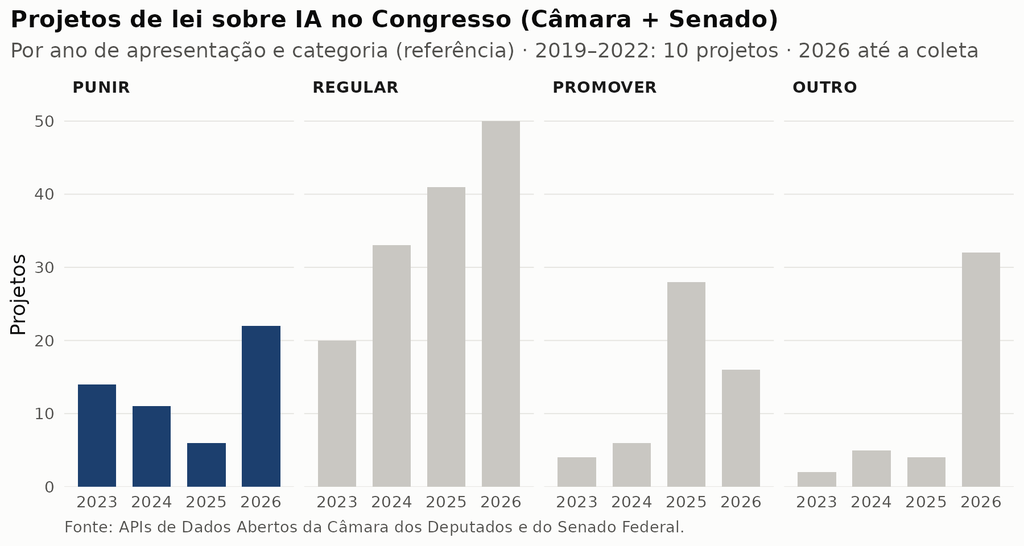

## A “atual fase” da estatística

- **Breiman (2001)**: duas culturas, *modelar* × *prever*
- **2018–2026**: a síntese, com ML a serviço da **inferência**
  - *Double ML* (Chernozhukov et al., 2018)
  - Predição conformal
  - *Prediction-Powered Inference* (Angelopoulos et al., *Science*, 2023)
  - *Design-based Supervised Learning* (Egami et al., 2023)

**Ideia central**

Um LLM é um **instrumento de medição**, como um questionário ou um codificador humano.

Instrumentos têm **validade**, **confiabilidade** e **viés**. Tudo isso se mede.

## O caminho de hoje

```
%%{init: {"theme": "base", "themeVariables": {"lineColor": "#8f8d88", "primaryColor": "#eef4fc", "primaryBorderColor": "#7ba4de", "primaryTextColor": "#0b0b0b", "fontFamily": "Source Sans Pro, Helvetica Neue, Arial, sans-serif"}}}%%
flowchart LR
  A[APIs<br>Câmara + Senado] --> B[Corpus<br>304 ementas]
  B --> C[Livro de códigos<br>+ amostra-ouro]
  C --> D[Baselines<br>dicionário · TF-IDF]
  B --> E[LLM local<br>3 prompts · cache]
  C --> F[Validação<br>kappa · viés · reteste]
  D --> F
  E --> F
  F --> G[Inferência<br>PPI]
  G --> H[Pipeline<br>targets]
  classDef foco fill:#1c3f6e,stroke:#1c3f6e,color:#ffffff
  class E foco
```

# 1 · Dados legislativos

## APIs de dados abertos

```r
library(httr2)
request("https://dadosabertos.camara.leg.br/api/v2/proposicoes") |>
  req_url_query(keywords = "inteligência artificial", ano = 2026,
                siglaTipo = "PL", itens = 100) |>
  req_headers(Accept = "application/json") |>
  req_perform() |>
  resp_body_json()
```

- Câmara: `dadosabertos.camara.leg.br/api/v2` · Senado: `legis.senado.leg.br/dadosabertos`
- Termos: *inteligência artificial*, *deepfake*, *deep fake*, *conteúdo sintético*
- 2019–2026 · Câmara: 260 · Senado: 44

## A coleta também é medição

- **Limite de 3 meses** no filtro de data → filtrar por `ano`
- **Partido “na data”**: a API da Câmara traz registros “partido no início da legislatura” **datados de 2023** para legislaturas antigas → um deputado do PL em 2023 aparecia como **PMDB** ou **PFL**
- **Busca por palavra-chave** depende de um indexador → falsos positivos (Lei Geral de Atividades Nucleares?) e possíveis omissões
- **Duplicatas**: PL do Senado remetido à Câmara aparece nas duas casas
- **“Campo político”** (Bolognesi, Ribeiro & Codato, 2023) é ele próprio uma medida

# 2 · Codificar é medir

## Livro de códigos

| Código | Instrumento central | Exemplo |
| --- | --- | --- |
| **PUNIR** | penal: crime, pena, Código Penal | “tipifica o crime de deepfake sexual” |
| **REGULAR** | regras não penais: deveres, rotulagem, direitos | “obriga identificar conteúdo gerado por IA” |
| **PROMOVER** | fomento, ensino, adoção pelo Estado | “inclui IA no currículo do ensino médio” |
| **OUTRO** | não trata de IA | falsos positivos da busca |

**Regras:** precedência PUNIR > REGULAR > PROMOVER · “penalidades” sem crime = REGULAR · + variável **eleitoral** (0/1)

# 3 · Baselines

## Quanto se acerta **sem** LLM?

| Método | Acurácia | F1 macro | Kappa |
| --- | --- | --- | --- |
| Dicionário (regex) | 81% | 0,78 | 0,70 |
| TF-IDF + logística (CV 10) | 68% | 0,50 | 0,41 |
| Classe majoritária (REGULAR) | 57% | 0,18 | 0,00 |

**Aviso**

O dicionário foi escrito **depois de ler as ementas**: ele “viu a prova”. Desempenho otimista = *data leakage*.

# 4 · O LLM como instrumento

## Um modelo aberto, em português, local e gratuito

```python
requests.post("http://localhost:11434/api/chat", json={
    "model": "s5-nano-instruct",               # S5-nano (Maritaca AI), 4 bits, ~3,5 GB
    "think": False,                            # modo instruct: responde sem "raciocinar"
    "format": ESQUEMA_JSON,                    # saída estruturada
    "options": {"temperature": 0, "seed": 42}, # registrar SEMPRE
    "messages": [{"role": "user", "content": prompt}],
})
```

- **S5-nano** (Maritaca AI): `ollama pull hf.co/maritaca-ai/S5-nano-GGUF:Q4_K_M` + `ollama create s5-nano-instruct`
- **Por que local?** Dados não saem da máquina · custo zero · **a versão não muda sem aviso**
- APIs comerciais: mesma interface, mas registre o modelo exato e a data
- ~0,4 s por ementa numa GPU de notebook → 304 ementas em ~2 min

## Por que o S5-nano?

- **Brasileiro:** desenvolvido pela Maritaca AI, com pré-treinamento adicional em **dados em português**, a língua (e o vocabulário jurídico-legislativo) das ementas
- **Vem do Qwen:** parte do **Qwen3.5-4B** (Alibaba) e herda dele a arquitetura, o tokenizador e boa parte do que “sabe”. O português ajusta o modelo-base, mas não apaga o que veio antes
- **Aberto e pequeno:** Apache-2.0, pesos públicos (todos baixam **a mesma versão**), roda numa GPU de notebook
- A origem faz parte da descrição do instrumento, e “brasileiro” **não garante validade**: é preciso medir na amostra-ouro

## O prompt é parte do instrumento

| Versão | Conteúdo |
| --- | --- |
| **v1** | só os nomes das categorias |
| **v2** | + definições e regras do livro de códigos |
| **v3** | + 6 exemplos **fictícios** (*few-shot*) |

Cada resposta fica em `dados/cache_llm/*.jsonl` com: modelo, **digest dos pesos**, **versão do Ollama**, `prompt_id`, **hash SHA-256 do prompt**, temperatura, semente, **resposta bruta**, rótulo extraído e tempo.

```
{"doc_id": "doc0033", "modelo": "s5-nano-instruct", "modelo_digest": "85ec77c8f04e", "ollama_versao": "0.40.15",
 "prompt_id": "v2", "prompt_sha": "c4b5a5ade801", "temperatura": 0.0, "semente": 42,
 "resposta_bruta": "{\"categoria\": \"PUNIR\", \"eleitoral\": true}", ...}
```

# 5 · Validação

## Validade: concordância com a amostra-ouro

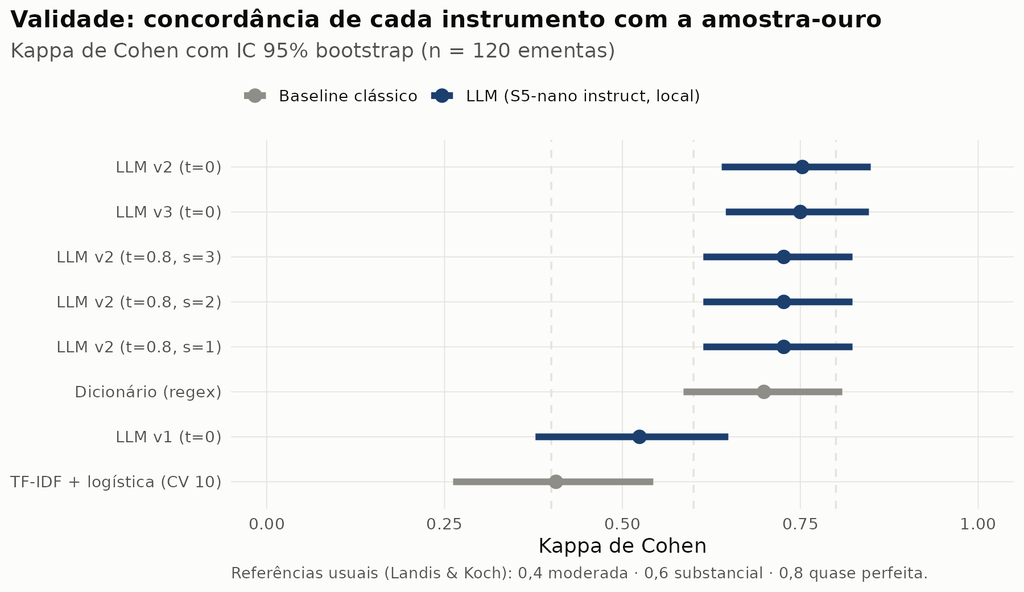

## Os números

| Instrumento | Falhas de formato | Acurácia | F1 macro | Kappa [IC 95%] |
| --- | --- | --- | --- | --- |
| LLM v2 (t=0) | 0% | 85% | 0,79 | 0,75 [0,64; 0,85] |
| LLM v3 (t=0) | 0% | 84% | 0,79 | 0,75 [0,65; 0,85] |
| LLM v2 (t=0.8, s=1) | 0% | 83% | 0,76 | 0,73 [0,61; 0,82] |
| LLM v2 (t=0.8, s=2) | 0% | 83% | 0,76 | 0,73 [0,61; 0,82] |
| LLM v2 (t=0.8, s=3) | 0% | 83% | 0,76 | 0,73 [0,61; 0,82] |
| Dicionário (regex) | 0% | 81% | 0,78 | 0,70 [0,59; 0,81] |
| LLM v1 (t=0) | 0% | 72% | 0,55 | 0,52 [0,38; 0,65] |
| TF-IDF + logística (CV 10) | 0% | 68% | 0,50 | 0,41 [0,26; 0,54] |

## Onde o instrumento erra

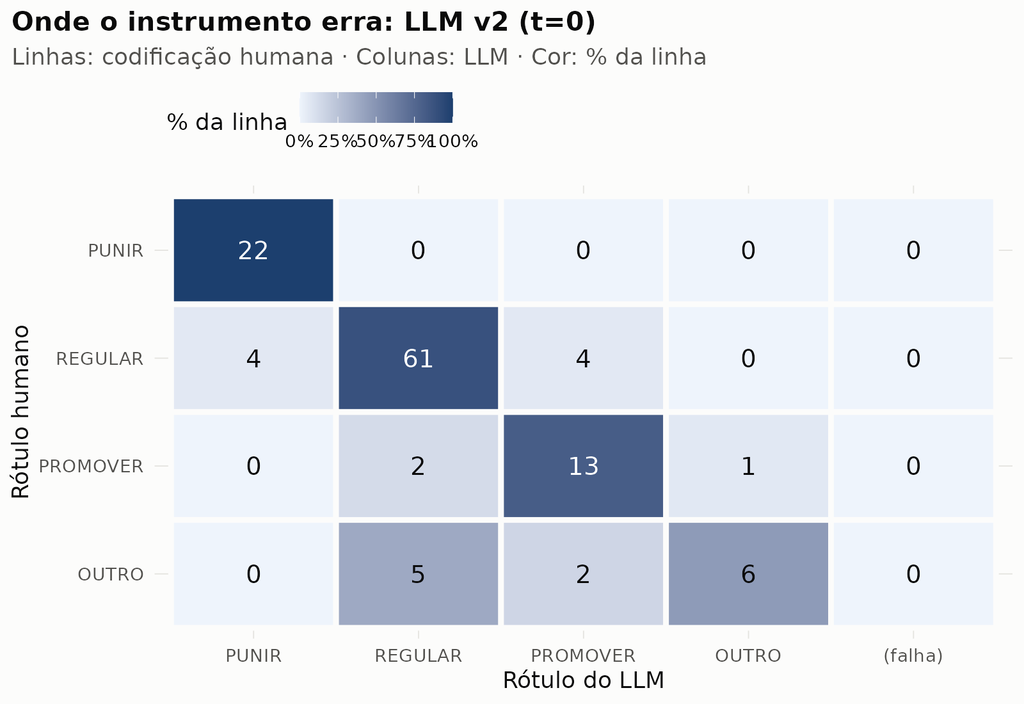

## Viés diferencial

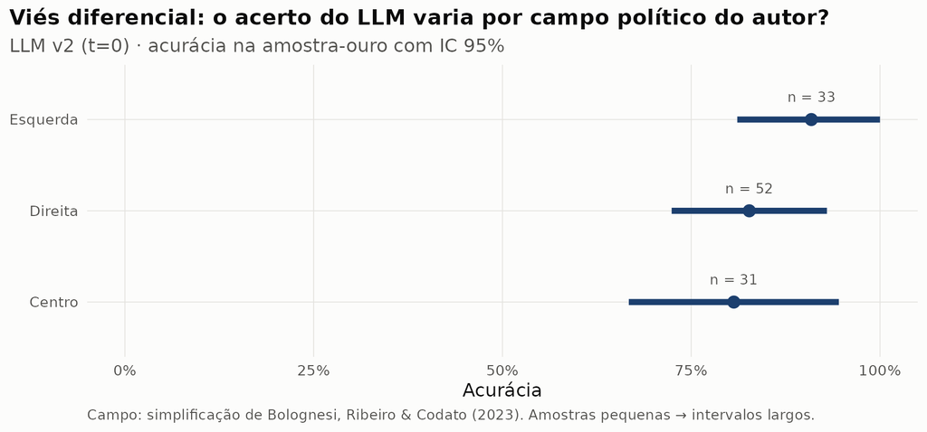

> Acurácia alta **na média** não garante comparações válidas **entre grupos**.

## Confiabilidade: o instrumento é estável?

| Comparação | Alfa de Krippendorff | % de ementas que mudam de rótulo |
| --- | --- | --- |
| Teste-reteste (v2, t=0,8, 3 sementes) | 1,00 | 0,0% |
| Sensibilidade ao prompt (v1, v2, v3; t=0) | 0,75 | 23,4% |

- **Teste-reteste**: mesmo prompt, mesma ementa, **sementes diferentes**
- **Sensibilidade ao prompt**: mesmo modelo, **três redações** do mesmo livro de códigos

## Mesmo modelo, prompts diferentes, medidas diferentes

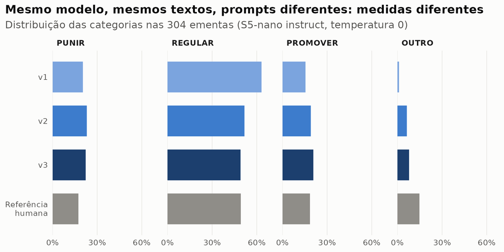

# 6 · Inferência com rótulos imperfeitos

## O problema

Queremos $\theta$ = proporção de projetos **PUNIR**.

**Só humanos** (amostra-ouro, $n$ = 120)

$$\hat\theta_H = \bar Y_n$$

sem viés, mas **impreciso**

**Ingênuo** (LLM em todo o corpus)

$$\hat\theta_{LLM} = \bar f_{N+n}$$

preciso, mas **enviesado** pelo erro do LLM

## *Prediction-Powered Inference* (Angelopoulos et al., 2023)

$$\hat\theta_{PP} = \underbrace{\frac{1}{N}\sum_{i=1}^{N} f(X_i)}_{\text{LLM no não rotulado}} \; - \; \underbrace{\frac{1}{n}\sum_{j=1}^{n}\big(f(X_j) - Y_j\big)}_{\text{viés do LLM medido na amostra-ouro}}$$

$$\widehat{\text{Var}}(\hat\theta_{PP}) = \frac{\hat\sigma^2_{f}}{N} + \frac{\hat\sigma^2_{f-Y}}{n}$$

- Sem hipótese sobre a qualidade do LLM: um LLM ruim gera **IC largo**, não **IC errado**
- **PPI++** pondera o LLM por $\lambda \in [0,1]$ (se o LLM for inútil, $\lambda \to 0$)
- Em R: são **5 linhas** (`R/funcoes_medicao.R`)

## Que proporção dos projetos quer PUNIR?

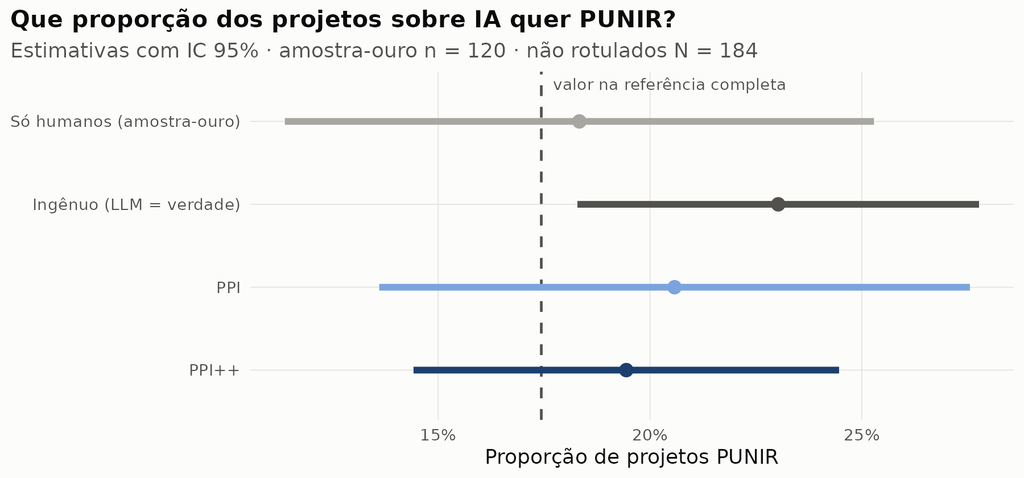

## Os números

| Estimador | Estimativa | IC 95% | Largura |
| --- | --- | --- | --- |
| Só humanos (amostra-ouro) | 18,3% | [11,4%; 25,3%] | 13,9% |
| Ingênuo (LLM = verdade) | 23,0% | [18,3%; 27,8%] | 9,5% |
| PPI | 20,6% | [13,6%; 27,6%] | 13,9% |
| PPI++ | 19,4% | [14,4%; 24,5%] | 10,0% |

Valor na referência completa (didático): **17,4%**

## O IC ingênuo engana: simulação

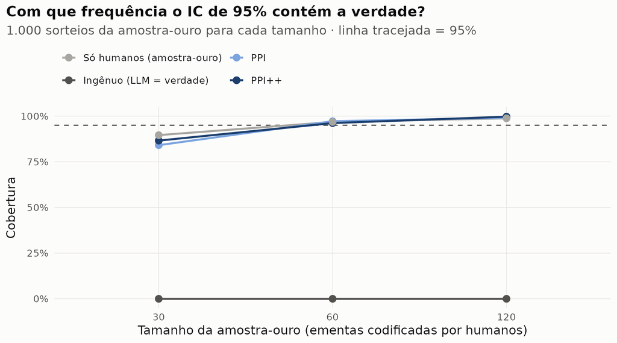

## O preço da honestidade

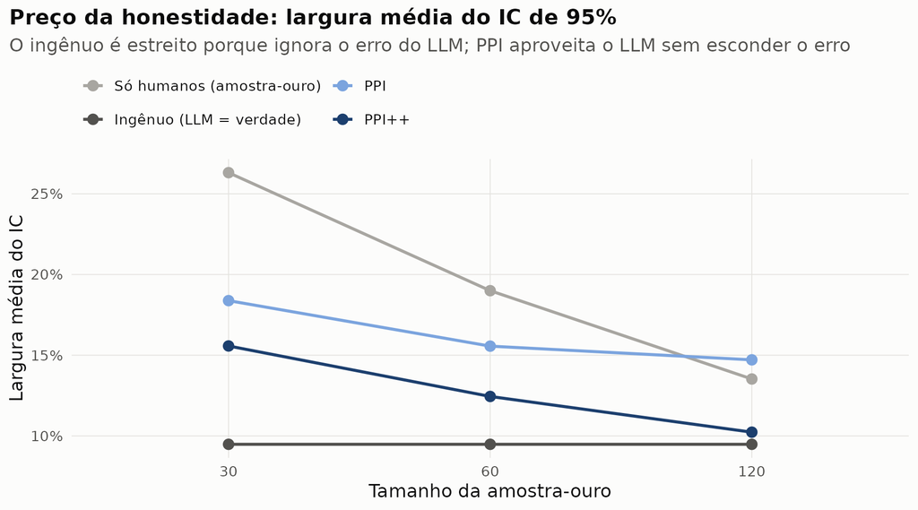

## O que os números dizem

- **LLM e dicionário empatam** (kappa 0,75 × 0,70, ICs sobrepostos), e o dicionário “viu a prova”. Num corpus novo, quem ganha?
- **O prompt importa mais que o acaso**: trocar a semente muda 0% dos rótulos; trocar o prompt muda 23%
- **O ingênuo superestima** a proporção punitiva (23% × 17,4% na referência) e seu IC **nunca** cobriu a verdade na simulação
- **PPI++** corrige o viés e entrega um IC 28% mais estreito que o “só humanos”
- **Resposta substantiva:** cerca de **19%** dos projetos sobre IA querem **punir** (PPI++, IC 14%–24%); metade **regula**

## E entre campos políticos?

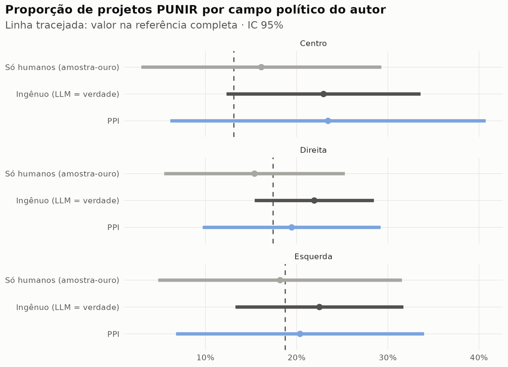

# 7 · Reprodutibilidade (MLOps)

## O que precisa ser versionado?

**Código** → Git

**Ambiente** → `renv` / `requirements.txt` / Docker

**Dados brutos** → congelados com data (APIs mudam!)

**Instrumento** → modelo + **prompt** (hash) + parâmetros

**Respostas do LLM** → cache (é dado, não lixo)

```r
# _targets.R
tar_target(arq_prompts,
  list.files("prompts", full.names = TRUE),
  format = "file")
tar_target(validacao,
  roda_script("R/05_validacao.R", ...,
    arq_cache_llm, arq_prompts))
```

```r
targets::tar_make()       # só o que mudou
targets::tar_outdated()   # editei o prompt v2...
targets::tar_visnetwork()
```

## *Drift*: quando o instrumento muda sozinho

- API comercial atualiza o modelo → **mesmo prompt, outra medida**
- Defesa: modelo local com versão fixa **ou** registrar `model_id` + data + respostas brutas
- Monitorar: re-anotar periodicamente a amostra-ouro e acompanhar o kappa
- **Mesmo local, t = 0 não é determinístico:** repetindo as 3 anotações do S5-nano, 5 de 912 rótulos mudaram (GPU) → a replicação vem do **cache**
- **Agentes de código** (Claude Code, Codex…) também produzem análises: **trate o código gerado como o de um coautor**, com revisão, testes e versionamento

# 8 · Ética, limites e debate

## IA na política brasileira em 2026

### Eleições (TSE)

- Res. 23.755/2026: **rotulagem** de conteúdo sintético
- **Deepfakes** proibidos, mesmo com autorização
- Vedação de novos conteúdos sintéticos **72h antes / 24h depois** da votação
- IA não pode **recomendar voto**

### Congresso

- **PL 2338/2023**: risco, direitos, SIA, sanções de até R$ 50 mi
- Na Câmara desde mar/2025; **aguardando parecer**
- Enquanto isso: 294 projetos desde 2023, muitos **punitivos** e **fragmentados**

## Para debater

1. Se um LLM classifica 304 ementas em poucos minutos, ainda precisamos de codificadores humanos? **Para quê, exatamente?**
2. Modelo **local** (reprodutível) com kappa menor × API **comercial** com kappa maior?
3. O **viés político** dos LLMs (Motoki et al., 2024) pode contaminar comparações entre campos? Como testar?
4. Rotulagem obrigatória de conteúdo sintético é **verificável**? Quem audita o detector?

## Quando **não** usar um LLM

- O conceito não tem **definição operacional** clara
- Não há como montar uma **amostra-ouro**
- O erro do modelo é **correlacionado** com a variável explicativa e não pode ser corrigido
- Poucos documentos: codificar à mão é mais barato e mais confiável
- Os dados não podem sair da instituição e não há modelo local adequado

## Mensagem final

**Importante**

A IA amplia as formas de responder,  
mas **não substitui** a boa pergunta, o desenho de pesquisa e a **validação estatística**.

- **Material completo:** repositório do minicurso (R + Python + dados + cache do LLM)
- **Checklist** para o seu próximo artigo: `CHECKLIST.md`

**Jodavid Ferreira** · jodavid.ferreira@ufpe.br · jodavid.github.io

## Referências

- Angelopoulos, A. N. et al. (2023). Prediction-powered inference. *Science*, 382(6671).
- Angelopoulos, A. N.; Duchi, J.; Zrnic, T. (2023). PPI++: Efficient prediction-powered inference. *arXiv:2311.01453*.
- Bolognesi, B.; Ribeiro, E.; Codato, A. (2023). A new ideological classification of Brazilian political parties. *Dados*, 66(2).
- Breiman, L. (2001). Statistical modeling: the two cultures. *Statistical Science*, 16(3).
- Chernozhukov, V. et al. (2018). Double/debiased machine learning. *The Econometrics Journal*, 21(1).
- Egami, N. et al. (2023). Using imperfect surrogates for downstream inference. *NeurIPS*.
- Gilardi, F.; Alizadeh, M.; Kubli, M. (2023). ChatGPT outperforms crowd workers for text-annotation tasks. *PNAS*, 120(30).
- Grimmer, J.; Roberts, M.; Stewart, B. (2022). *Text as Data*. Princeton University Press.
- Krippendorff, K. (2018). *Content Analysis* (4ª ed.). SAGE.
- Landau, W. M. (2021). The targets R package. *JOSS*, 6(57).
- Motoki, F.; Pinho Neto, V.; Rodrigues, V. (2024). More human than human: measuring ChatGPT political bias. *Public Choice*, 198.
- Tribunal Superior Eleitoral. Resolução nº 23.755, de 2 de março de 2026.